# R Open Labs 2 - Importing, Manipulating and Exporting Data

Chelsea Estancona

9/7/2017

### Working directories, accessing data, and exporting data

R can read and write a number of different file types – it’s a very flexible tool for working with data produced in other settings. To see whether or not your file can be read into R, and for an additional resource after this session:

https://www.datacamp.com/community/tutorials/r-data-import-tutorial#gs.R2X2U4c

Prior to reading in any files, it’s helpful to know where R would default to pulling files in from. This is called your working directory – and R always has one set.

```r
getwd()
```

```
## [1] "/Users/chelseaestancona/Dropbox/Teaching/POLI784"
```

We can see here that I’m saving everything I produce and pulling files from a folder I have designated for R open labs.

When working on a project, it can be helpful to move everything into one single working directory, which we set as below:

```r
setwd("/Users/chelseaestancona/Dropbox/Teaching/POLI784/")
getwd() #check if it's changed
```

```
## [1] "/Users/chelseaestancona/Dropbox/Teaching/POLI784"
```

This means that any data I bring in or anything I save now goes to this folder.

We can still bring in files from other directories, however, by including the full file name.

First, though, we need to make sure we have the correct package loaded for R to read other types of data:

```r
#install.packages("foreign") -- uncomment as needed
library(foreign)
```

Let’s experiment with a .dta (Stata) file:

```r
# Specify a path:
path <- "/Users/chelseaestancona/Dropbox/Teaching/POLI784/Lab_9_Data.dta"

# Assign data to an object for easier future use- we can do this because we installed the foreign package
# and brought it into our current R with library()

My_data <- read.dta(path)
```

We can combine this to a single step, rather than making a path, and using our working directory:

```r
My_data_2<-read.dta("Lab_9_Data.dta")
```

The syntax for bringing in data of other formats is remarkably similar – we simply change what follows the ‘read.’: read.csv, read.txt, etc.

R is also handy in that it can read data that’s provided directly through a website.

```r
path.2 <- "http://www.unc.edu/~bdlacree/doc/POLI783/data/approval.csv"
approval_data <- read.csv(url(path.2), header=T) #note the combined parentheses, and use of a csv.
```

Let’s use our indexing and previously used skills to check our new data:

```r
is.data.frame(approval_data)
```

```
## [1] TRUE
```

```r
n <- nrow(approval_data)
m <- ncol(approval_data)
dim(approval_data)
```

```
## [1] 55  4
```

And perhaps let’s change a column name before we export our newly changed data:

```r
colnames(approval_data)
```

```
## [1] "Year"         "Month"        "Approval"     "Unemployment"
```

```r
colnames(approval_data)[3]<-"Rating"
```

Finally, to export data out of R (where will this go?) we can use very similar language:

```r
write.dta(approval_data, "approval.dta")
```

### Libraries and Packages

To get our data into R, we installed and called the ‘foreign’ package. We can repeat this process for a variety of other packages we might be interested in. Note that packages are in quotes when we first install them – we only need to do this once. We use the library () command, however, every time we re-open R.

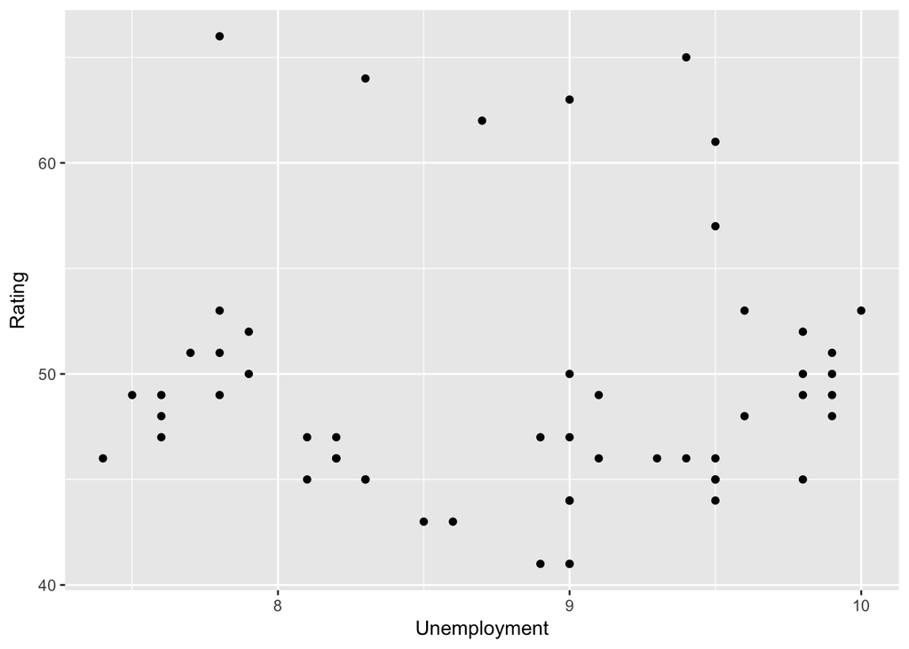

```r
#install.packages("ggplot2") #for professional plots
library(ggplot2)

ggplot(data=approval_data, aes(x=Unemployment, y=Rating)) + geom_point()
```

Take a few minutes to search for available R packages (if you’re stuck, try here: https://cran.r-project.org/web/packages/available_packages_by_name.html) install and call one that could be relevant for your work.